# Complete Analysis

```r
library(tidyverse)
library(ggpubr)
```

# Data Import

We have 60 sets of data in total. Each set represents a single trial of PM2.5, PM10 readings for one group from the control and treatment groups. Each trial was conducted using one of three sensor-box combinations (1a, 2b, or 3d).

Here, we define a function which will

1. Import a trial,
2. Add a column to documents its sensor-box and another for its group,
3. Divide the PM2.5 and PM10 readings, then for each of the two reading types:
4. Trim away all the readings before the first time the sensor desaturates, and
5. Set the time column as being the seconds since the first desaturated reading.

By desaturation, we mean the first reading which falls within the sensor’s specified range. For our model of PM sensor, this is defined as [0, 999.9] micrograms per cubic metre.

```r
import <- function(filename) {
  data <- read_csv(filename, col_names=c('time', 'type', 'value'))
  data <- list(
    pm2.5=(data %>%
      subset(type=='pm2.5') %>%
      mutate(value=as.numeric(value)) %>%
      mutate(time=as.numeric(as.POSIXct(time)))),
    pm10=(data %>%
      subset(type=='pm10') %>%
      mutate(value=as.numeric(value)) %>%
      mutate(time=as.numeric(as.POSIXct(time))))
  )

  if (grepl('nothing', filename, fixed=T)) {
    data$group <- 'nothing'
  }
  else if (
    grepl('plant', filename, fixed=T) &
    !grepl('deadplant', filename, fixed=T)
  ) {
    data$group <- 'plant'
  }
  else if (grepl('deadplant', filename, fixed=T)) {
    data$group <- 'deadplant'
  } else if (grepl('soil', filename, fixed=T)) {
    data$group <- 'soil'
  } else {
    stop(paste('import: Invaid group in', filename))
  }

  if(grepl('1[aA]', filename)) {
    data$sensorbox <- '1a'
  } else if (grepl('2[bB]', filename)) {
    data$sensorbox <- '2b'
  } else if (grepl('3[dD]', filename)) {
    data$sensorbox <- '3d'
  } else {
    stop(paste('import: Invalid sensor-box in', filename))
  }

  pm2.5_last_saturated <- last(which(data$pm2.5$value>=999.9))
  data$pm2.5 <- data$pm2.5[-(1:pm2.5_last_saturated),]
  pm10_last_saturated <- last(which(data$pm10$value>=999.9))
  data$pm10 <- data$pm10[-(1:pm10_last_saturated),]

  data$pm2.5$time <- data$pm2.5$time - data$pm2.5$time[1]
  data$pm10$time <- data$pm10$time - data$pm10$time[1]

  return(data)
}
```

Then, we import all our data by first building a vector of their filenames.

```r
filenames <- c(
  '19-octa-nothing-1a.csv',  '19-octa-nothing-2b.csv', '19-octa-nothing-3d.csv',
  '20octa-nothing1a.csv',    '20octa-nothing2b.csv',   '20octa-nothing3d.csv',
  '21octa-nothing-1a.csv',   '21octa-nothing-2b.csv',  '21octa-nothing-3d.csv',
  '21octb-nothing-1a.csv',   '21octb-nothing-2b.csv',  '21octb-nothing-3d.csv',
  '22octa-nothing-1a.csv',   '22octa-nothing-2b.csv',  '22octa-nothing-3d.csv',
  '25octa-deadplant-1a.csv', '25octa-plant-3D.csv',    '25octa-soil-2b.csv',
  '25octb-deadplant-1a.csv', '25octb-plant-3D.csv',    '25octb-soil-2b.csv',
  '26octa-deadplant-1a.csv', '26octa-plant-3d.csv',    '26octa-soil-2b.csv',
  '27octa-deadplant-1a.csv', '27octa-plant-3d.csv',    '27octa-soil-2b.csv',
  '28octa-deadplant-1a.csv', '28octa-plant-3d.csv',    '28octa-soil-2b.csv',
  '2nova-deadplant-2b.csv',  '2nova-plant-1a.csv',     '2nova-soil-3d.csv',
  '2novb-deadplant-2b.csv',  '2novb-plant-1a.csv',     '2novb-soil-3d.csv',
  '30octa-deadplant-2b.csv', '30octa-plant-1a.csv',    '30octa-soil-3d.csv',
  '30octb-deadplant-2b.csv', '30octb-plant-1a.csv',    '30octb-soil-3d.csv',
  '31octb-deadplant-2b.csv', '31octb-plant-1a.csv',    '31octb-soil-3d.csv',
  '3nova-deadplant-3d.csv',  '3nova-plant-2b.csv',     '3nova-soil-1a.csv',
  '4nova-deadplant-3d.csv',  '4nova-plant-2b.csv',     '4nova-soil-1a.csv',
  '5nova-deadplant-3d.csv',  '5nova-plant-2b.csv',     '5nova-soil-1a.csv',
  '6nova-deadplant-3d.csv',  '6nova-plant-2b.csv',     '6nova-soil-1a.csv',
  '7nova-plant-2b.csv',  '7nova-deadplant-3d.csv', '7nova-soil-1a.csv'
)
```

Followed by an `lapply` of the `import` function over the filenames vector to obtain a list of lists. Each nested list is a trial.

```r
data <- lapply(filenames, function(fn) {
  import(paste('05-analysis-proper/', fn, sep=''))})
```

# Sensor Calibration

But, each sensor labelled 1 to 3 are not calibrated with each other. Given the same ‘air’, they give different readings. In order to calibrate these sensors, we use a set of time-synchronised readings between the 3 sensors, where

- Each sensor is placed in the same box and reads during the same session, and
- Each sensor reads within 5s of each other.

An arbitrary sensor, the one labelled 3, is selected as the baseline for calibration.

First, load the readings for the individual sensors. Then, combine them into one tibble. Note that each sensor’s time stamp is synchronised because they are given by the same raspberry pi zero computer.

```r
import_cdata <- function(filename) {
  data <- filename %>%
    read_csv(col_names=c('time', 'type', 'value')) %>%
    subset(type != 'comment') %>%
    mutate(value=as.numeric(value)) %>%
    mutate(time=as.numeric(as.POSIXct(time)))
}

# The three sensors were set-up such that they all began at the same time, +- 1s.
sensor1 <- import_cdata('03-sensor-calibration/16octc-nothing-1bigbox.csv')
sensor2 <- import_cdata('03-sensor-calibration/16octc-nothing-2bigbox.csv')
sensor3 <- import_cdata('03-sensor-calibration/16octc-nothing-3bigbox.csv')

# Some times, the an interval (supposedly per-minute) fails to read, and a row is missing.
# So, we want to make sure that each row index of sensor 1/2 aligns with sensor 3.
grouped_pm2.5 <- tibble(s1=double(), s2=double(), s3=double())
sensor1_pm2.5 <- subset(sensor1, type=='pm2.5')
sensor2_pm2.5 <- subset(sensor2, type=='pm2.5')
sensor3_pm2.5 <- subset(sensor3, type=='pm2.5')
# Also, trim the pre-desaturation data. The 999.9 are outliers with high leverage, and the
# data leading up to saturation is high variance.
last_saturated <- max(
  last(which(sensor1_pm2.5$value >= 999.9)),
  last(which(sensor2_pm2.5$value >= 999.9)),
  last(which(sensor3_pm2.5$value >= 999.9))
)
sensor1_pm2.5 <- sensor1_pm2.5[-(1:last_saturated),]
sensor2_pm2.5 <- sensor2_pm2.5[-(1:last_saturated),]
sensor3_pm2.5 <- sensor3_pm2.5[-(1:last_saturated),]
for (i in seq(1, nrow(sensor3_pm2.5))) {
  s3 <- sensor3_pm2.5[i,]
  s1 <- sensor1_pm2.5 %>% mutate(time=time-s3[1,]$time) %>% subset(abs(time) <= 5)
  s2 <- sensor2_pm2.5 %>% mutate(time=time-s3[1,]$time) %>% subset(abs(time) <= 5)
  if (nrow(s1) == 0 & nrow(s2) == 0) {
    next
  } else if (nrow(s1) == 0) {
    grouped_pm2.5 <- bind_rows(grouped_pm2.5, list(s1=NA, s2=s2[1,]$value, s3=s3[1,]$value))
  } else if (nrow(s2) == 0) {
    grouped_pm2.5 <- bind_rows(grouped_pm2.5, list(s1=s1[1,]$value, s2=NA, s3=s3[1,]$value))
  } else {
    grouped_pm2.5 <- bind_rows(grouped_pm2.5, list(s1=s1[1,]$value, s2=s2[1,]$value, s3=s3[1,]$value))
  }
}
# Repeat for PM10...
grouped_pm10 <- tibble(s1=double(), s2=double(), s3=double())
sensor1_pm10 <- subset(sensor1, type=='pm10')
sensor2_pm10 <- subset(sensor2, type=='pm10')
sensor3_pm10 <- subset(sensor3, type=='pm10')
last_saturated <- max(
  last(which(sensor1_pm10$value >= 999.9)),
  last(which(sensor2_pm10$value >= 999.9)),
  last(which(sensor3_pm10$value >= 999.9))
)
sensor1_pm10 <- sensor1_pm10[-(1:last_saturated),]
sensor2_pm10 <- sensor2_pm10[-(1:last_saturated),]
sensor3_pm10 <- sensor3_pm10[-(1:last_saturated),]
for (i in seq(1, nrow(sensor3_pm10))) {
  s3 <- sensor3_pm10[i,]
  s1 <- sensor1_pm10 %>% mutate(time=time-s3[1,]$time) %>% subset(abs(time) <= 5)
  s2 <- sensor2_pm10 %>% mutate(time=time-s3[1,]$time) %>% subset(abs(time) <= 5)
  if (nrow(s1) == 0 & nrow(s2) == 0) {
    next
  } else if (nrow(s1) == 0) {
    grouped_pm10 <- bind_rows(grouped_pm10, list(s1=NA, s2=s2[1,]$value, s3=s3[1,]$value))
  } else if (nrow(s2) == 0) {
    grouped_pm10 <- bind_rows(grouped_pm10, list(s1=s1[1,]$value, s2=NA, s3=s3[1,]$value))
  } else {
    grouped_pm10 <- bind_rows(grouped_pm10, list(s1=s1[1,]$value, s2=s2[1,]$value, s3=s3[1,]$value))
  }
}

data_calibration <- list(pm2.5=grouped_pm2.5, pm10=grouped_pm10)
```

A quick graphical check to show that the sensors are indeed different:

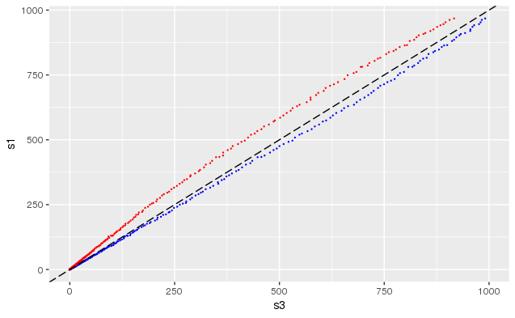

```r
ggplot(data_calibration$pm2.5) +
  geom_point(mapping=aes(x=s3, y=s1), size=.2, colour='blue') +
  geom_point(mapping=aes(x=s2, y=s1), size=.2, colour='red') +
  geom_abline(linetype='longdash')
```

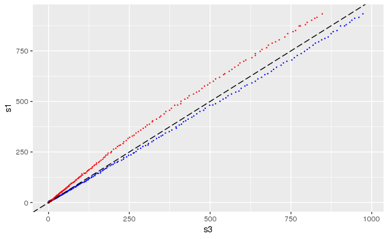

```r
ggplot(data_calibration$pm10) +
  geom_point(mapping=aes(x=s3, y=s1), size=.2, colour='blue') +
  geom_point(mapping=aes(x=s2, y=s1), size=.2, colour='red') +
  geom_abline(linetype='longdash')
```

Now, the calibration via regression.

```r
calibration <- list(
  pm2.5=list(
    s1=lm(s1~s3+I(s3^2), data=data_calibration$pm2.5),
    s2=lm(s2~s3+I(s3^2), data=data_calibration$pm2.5)
  ),
  pm10=list(
    s1=lm(s1~s3+I(s3^2), data=data_calibration$pm10),
    s2=lm(s2~s3+I(s3^2), data=data_calibration$pm10)
  )
)

summary(calibration$pm2.5$s1)
```

```
Call:
lm(formula = s1 ~ s3 + I(s3^2), data = data_calibration$pm2.5)

Residuals:
     Min       1Q   Median       3Q      Max
-11.9730  -0.3237  -0.2314   0.2253  10.5947

Coefficients:
             Estimate Std. Error t value Pr(>|t|)
(Intercept) 3.696e-01  7.396e-02   4.997 7.19e-07 ***
s3          9.236e-01  1.121e-03 823.930  < 2e-16 ***
I(s3^2)     4.531e-05  1.392e-06  32.559  < 2e-16 ***
---
Signif. codes:
0 ‘***’ 0.001 ‘**’ 0.01 ‘*’ 0.05 ‘.’ 0.1 ‘ ’ 1

Residual standard error: 1.851 on 783 degrees of freedom
  (10 observations deleted due to missingness)
Multiple R-squared:  0.9999,    Adjusted R-squared:  0.9999
F-statistic: 5.05e+06 on 2 and 783 DF,  p-value: < 2.2e-16
```

```r
summary(calibration$pm2.5$s2)
```

```
Call:
lm(formula = s2 ~ s3 + I(s3^2), data = data_calibration$pm2.5)

Residuals:
     Min       1Q   Median       3Q      Max
-14.6745  -0.4492  -0.3537  -0.0691  13.3057

Coefficients:
             Estimate Std. Error t value Pr(>|t|)
(Intercept) 5.581e-01  9.175e-02   6.083 1.84e-09 ***
s3          6.517e-01  1.384e-03 471.028  < 2e-16 ***
I(s3^2)     2.618e-04  1.705e-06 153.538  < 2e-16 ***
---
Signif. codes:
0 ‘***’ 0.001 ‘**’ 0.01 ‘*’ 0.05 ‘.’ 0.1 ‘ ’ 1

Residual standard error: 2.303 on 786 degrees of freedom
  (7 observations deleted due to missingness)
Multiple R-squared:  0.9999,    Adjusted R-squared:  0.9999
F-statistic: 2.642e+06 on 2 and 786 DF,  p-value: < 2.2e-16
```

```r
summary(calibration$pm10$s1)
```

```
Call:
lm(formula = s1 ~ s3 + I(s3^2), data = data_calibration$pm10)

Residuals:
     Min       1Q   Median       3Q      Max
-10.1701  -0.8193  -0.3620   0.7817  11.9315

Coefficients:
             Estimate Std. Error t value Pr(>|t|)
(Intercept) 1.140e+00  6.993e-02   16.31   <2e-16 ***
s3          9.297e-01  1.130e-03  822.51   <2e-16 ***
I(s3^2)     2.480e-05  1.478e-06   16.78   <2e-16 ***
---
Signif. codes:
0 ‘***’ 0.001 ‘**’ 0.01 ‘*’ 0.05 ‘.’ 0.1 ‘ ’ 1

Residual standard error: 1.74 on 763 degrees of freedom
  (10 observations deleted due to missingness)
Multiple R-squared:  0.9999,    Adjusted R-squared:  0.9999
F-statistic: 4.267e+06 on 2 and 763 DF,  p-value: < 2.2e-16
```

```r
summary(calibration$pm10$s2)
```

```
Call:
lm(formula = s2 ~ s3 + I(s3^2), data = data_calibration$pm10)

Residuals:
     Min       1Q   Median       3Q      Max
-10.4328  -0.9058  -0.6122   0.8488   8.6659

Coefficients:
             Estimate Std. Error t value Pr(>|t|)
(Intercept) 1.070e+00  7.097e-02   15.08   <2e-16 ***
s3          6.773e-01  1.137e-03  595.55   <2e-16 ***
I(s3^2)     1.937e-04  1.476e-06  131.26   <2e-16 ***
---
Signif. codes:
0 ‘***’ 0.001 ‘**’ 0.01 ‘*’ 0.05 ‘.’ 0.1 ‘ ’ 1

Residual standard error: 1.772 on 766 degrees of freedom
  (7 observations deleted due to missingness)
Multiple R-squared:  0.9999,    Adjusted R-squared:  0.9999
F-statistic: 3.118e+06 on 2 and 766 DF,  p-value: < 2.2e-16
```

Finally, package it all into a function.

```r
calibrate_one <- function(pm, sensorbox, x) {
  if (is.na(x)) return(NA)
  if (pm == 'pm2.5' & sensorbox == '1a') {
    lm_obj <- calibration$pm2.5$s1
  } else if (pm == 'pm2.5' & sensorbox == '2b') {
    lm_obj <- calibration$pm2.5$s2
  } else if (pm == 'pm10' & sensorbox == '1a') {
    lm_obj <- calibration$pm10$s1
  } else if (pm == 'pm10' & sensorbox == '2b') {
    lm_obj <- calibration$pm10$s2
  } else {
    stop(paste('Invalid pm/sensorbox: ', pm, sensorbox))
  }
  coeff <- lm_obj$coefficients - c(x, 0, 0)
  roots <- Re(polyroot(coeff))
  root <- roots[roots>=0]
  if (length(root) == 1) return(root)
  return(NA)  # would use NULL, but can't have NA in the middle of a vector
}

calibrate <- function(pm, sensorbox, xs) {
  return(unlist(Map(
    function(x) calibrate_one(pm, sensorbox, x), xs)))
}
```

Some closing graphical sanity checks:

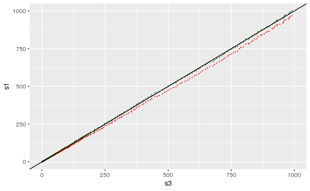

```r
ggplot(data_calibration$pm2.5 %>% mutate(s1.fix=calibrate('pm2.5', '1a', s1))) +
  geom_point(mapping=aes(x=s3, y=s1), colour='red', size=.2) +
  geom_point(mapping=aes(x=s3, y=s1.fix), colour='darkgreen', size=.2) +
  geom_abline()
```

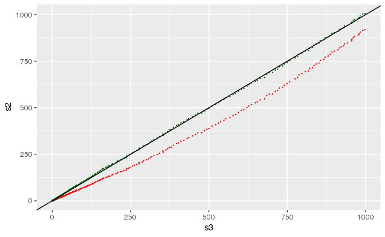

```r
ggplot(data_calibration$pm2.5 %>% mutate(s2.fix=calibrate('pm2.5', '2b', s2))) +
  geom_point(mapping=aes(x=s3, y=s2), colour='red', size=.2) +
  geom_point(mapping=aes(x=s3, y=s2.fix), colour='darkgreen', size=.2) +
  geom_abline()
```

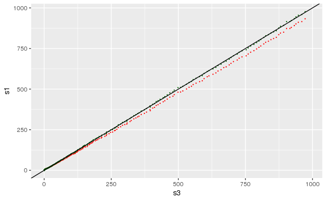

```r
ggplot(data_calibration$pm10 %>% mutate(s1.fix=calibrate('pm10', '1a', s1))) +
  geom_point(mapping=aes(x=s3, y=s1), colour='red', size=.2) +
  geom_point(mapping=aes(x=s3, y=s1.fix), colour='darkgreen', size=.2) +
  geom_abline()
```

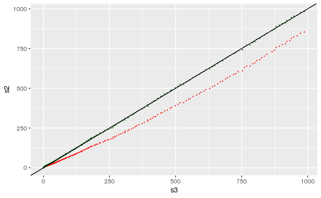

```r
ggplot(data_calibration$pm10 %>% mutate(s2.fix=calibrate('pm10', '2b', s2))) +
  geom_point(mapping=aes(x=s3, y=s2), colour='red', size=.2) +
  geom_point(mapping=aes(x=s3, y=s2.fix), colour='darkgreen', size=.2) +
  geom_abline()
```

# PM2.5 Box Plot & Multilinear Regression

First, calibrate the data.

```r
data_calibrated <- data %>%
  lapply(function(trial) {
    if (trial$sensorbox == '1a') {
      trial$pm2.5$value <- calibrate('pm2.5', '1a', trial$pm2.5$value)
      trial$pm10$value <- calibrate('pm10', '1a', trial$pm10$value)
    } else if (trial$sensorbox == '2b') {
      trial$pm2.5$value <- calibrate('pm2.5', '2b', trial$pm2.5$value)
      trial$pm10$value <- calibrate('pm10', '2b', trial$pm10$value)
    } else if (trial$sensorbox == '3d') {
      # noop
    } else {
      stop(paste('Invalid sensorbox', trial$sensorbox))
    }
    return(trial)
  })
```

Now, create a new tibble which records the PM decrease 2 hours after the first sub-900 micrograms per cubic metre reading.

```r
pm2.5_aggregated <- lapply(data_calibrated, function(trial) {
  last_super900 <- last(which(trial$pm2.5$value >= 900))
  valid_readings <- trial$pm2.5[-(1:last_super900),]
  initial_reading <- valid_readings[1,]$value
  readings_aft_2hrs <- valid_readings %>%
    mutate(time=time-(2*60*60)-valid_readings[1,]$time) %>%
    subset(abs(time) <= 5)
  last_reading <- readings_aft_2hrs[1,]$value
  list(sensorbox=trial$sensorbox, group=trial$group, decrease=initial_reading-last_reading)
})

pm2.5_decrease <- tibble(
  sensorbox=sapply(pm2.5_aggregated, function(xs) xs$sensorbox),
  group=sapply(pm2.5_aggregated, function(xs) xs$group),
  decrease=sapply(pm2.5_aggregated, function(xs) xs$decrease)
)

pm2.5_decrease$has_soil <- ifelse(pm2.5_decrease$group %in% c('soil', 'deadplant', 'plant'), 1, 0)
pm2.5_decrease$has_sa <- ifelse(pm2.5_decrease$group %in% c('deadplant', 'plant'), 1, 0)
pm2.5_decrease$has_life <- ifelse(pm2.5_decrease$group == 'plant', 1, 0)
```

The multilinear regression:

```r
pm2.5_decrease.lm <- lm(decrease~has_soil + has_sa + has_life + sensorbox, data=pm2.5_decrease)
summary(pm2.5_decrease.lm)
```

```
Call:
lm(formula = decrease ~ has_soil + has_sa + has_life + sensorbox,
    data = pm2.5_decrease)

Residuals:
    Min      1Q  Median      3Q     Max
-75.871 -27.387  -0.537  26.972  75.107

Coefficients:
            Estimate Std. Error t value Pr(>|t|)
(Intercept)   602.72      11.94  50.468  < 2e-16 ***
has_soil       88.01      13.79   6.382 4.14e-08 ***
has_sa         49.05      13.79   3.557 0.000791 ***
has_life      -40.37      13.79  -2.927 0.004993 **
sensorbox2b   115.36      11.94   9.660 2.29e-13 ***
sensorbox3d  -118.51      11.94  -9.923 8.98e-14 ***
---
Signif. codes:
0 ‘***’ 0.001 ‘**’ 0.01 ‘*’ 0.05 ‘.’ 0.1 ‘ ’ 1

Residual standard error: 37.77 on 54 degrees of freedom
Multiple R-squared:  0.9005,    Adjusted R-squared:  0.8913
F-statistic: 97.73 on 5 and 54 DF,  p-value: < 2.2e-16
```

The boxplot:

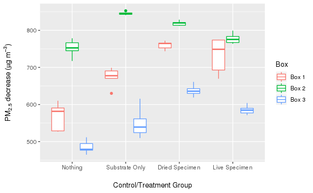

```r
groups <- factor(pm2.5_decrease$group, levels=c('nothing', 'soil', 'deadplant', 'plant'))
pm2.5_decrease$group <- groups

ggboxplot(pm2.5_decrease, x='group', y='decrease', color='sensorbox') +
    ylab(expression(atop("PM"[2.5]*" decrease ("*mu*"g m"^-3*")", ""))) +
    xlab("\nControl/Treatment Group") +
    guides(color=guide_legend(title='Box')) +
    scale_x_discrete(labels=c(
        'nothing'='Nothing',
        'soil'='Substrate Only',
        'deadplant'=expression('Dried Specimen'),
        'plant'=expression('Live Specimen'))) +
    scale_color_discrete(labels=c('Box 1', 'Box 2', 'Box 3')) +
    theme_grey()
ggsave('boxplot-pm25.eps', width=9, height=5)
```

# PM10 Boxplot & Multilinear Regression

```r
pm10_aggregated <- lapply(data_calibrated, function(trial) {
  last_super900 <- last(which(trial$pm10$value >= 900))
  valid_readings <- trial$pm10[-(1:last_super900),]
  initial_reading <- valid_readings[1,]$value
  readings_aft_2hrs <- valid_readings %>%
    mutate(time=time-(2*60*60)-valid_readings[1,]$time) %>%
    subset(abs(time) <= 5)
  last_reading <- readings_aft_2hrs[1,]$value
  list(sensorbox=trial$sensorbox, group=trial$group, decrease=initial_reading-last_reading)
})

pm10_decrease <- tibble(
  sensorbox=sapply(pm10_aggregated, function(xs) xs$sensorbox),
  group=sapply(pm10_aggregated, function(xs) xs$group),
  decrease=sapply(pm10_aggregated, function(xs) xs$decrease)
)

pm10_decrease$has_soil <- ifelse(pm10_decrease$group %in% c('soil', 'deadplant', 'plant'), 1, 0)
pm10_decrease$has_sa <- ifelse(pm10_decrease$group %in% c('deadplant', 'plant'), 1, 0)
pm10_decrease$has_life <- ifelse(pm10_decrease$group == 'plant', 1, 0)
```

The multilinear regression:

```r
pm10_decrease.lm <- lm(decrease~has_soil + has_sa + has_life + sensorbox, data=pm10_decrease)
summary(pm10_decrease.lm)
```

```
Call:
lm(formula = decrease ~ has_soil + has_sa + has_life + sensorbox,
    data = pm10_decrease)

Residuals:
   Min     1Q Median     3Q    Max
-57.62 -24.07  -0.31  21.09  63.87

Coefficients:
            Estimate Std. Error t value Pr(>|t|)
(Intercept)  650.776      9.857  66.023  < 2e-16 ***
has_soil      79.431     11.382   6.979 4.46e-09 ***
has_sa        42.076     11.382   3.697 0.000512 ***
has_life     -36.769     11.382  -3.231 0.002106 **
sensorbox2b   96.619      9.857   9.802 1.38e-13 ***
sensorbox3d -103.675      9.857 -10.518 1.11e-14 ***
---
Signif. codes:
0 ‘***’ 0.001 ‘**’ 0.01 ‘*’ 0.05 ‘.’ 0.1 ‘ ’ 1

Residual standard error: 31.17 on 54 degrees of freedom
Multiple R-squared:  0.9082,    Adjusted R-squared:  0.8997
F-statistic: 106.9 on 5 and 54 DF,  p-value: < 2.2e-16
```

The boxplot:

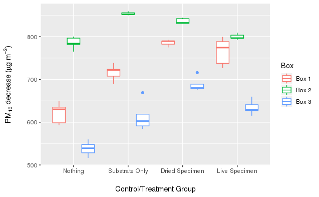

```r
groups <- factor(pm10_decrease$group, levels=c('nothing', 'soil', 'deadplant', 'plant'))
pm10_decrease$group <- groups

ggboxplot(pm10_decrease, x='group', y='decrease', color='sensorbox') +
    ylab(expression(atop("PM"[10]*" decrease ("*mu*"g m"^-3*")", ""))) +
    xlab("\nControl/Treatment Group") +
    guides(color=guide_legend(title='Box')) +
    scale_x_discrete(labels=c(
        'nothing'='Nothing',
        'soil'='Substrate Only',
        'deadplant'=expression('Dried Specimen'),
        'plant'=expression('Live Specimen'))) +
        scale_color_discrete(labels=c('Box 1', 'Box 2', 'Box 3')) +
    theme_grey()
ggsave('boxplot-pm10.eps', width=9, height=5)
```